# Supervised Machine Learning Techniques Assignment II

Shiyu Hua

#### Load the dataset

```python
import pandas as pd
path = 'C:/Users/lilyh/Desktop/final semester/5420/assignment3/'
df = pd.read_csv(path + 'XYZloan_default_selected_vars.csv') #, encoding = "ISO-8859-1")
df.head()
```

|  | Unnamed: 0.1 | Unnamed: 0 | id | loan_default | AP001 | AP002 | AP003 | AP004 | AP005 | AP006 | ... | CD162 | CD164 | CD166 | CD167 | CD169 | CD170 | CD172 | CD173 | MB005 | MB007 |
| --- | --- | --- | --- | --- | --- | --- | --- | --- | --- | --- | --- | --- | --- | --- | --- | --- | --- | --- | --- | --- | --- |
| 0 | 0 | 1 | 1 | 1 | 31 | 2 | 1 | 12 | 2017/7/6 10:21 | ios | ... | 13.0 | 13.0 | 0.0 | 0.0 | 1449.0 | 1449.0 | 2249.0 | 2249.0 | 7.0 | IPHONE7 |
| 1 | 1 | 2 | 2 | 0 | 27 | 1 | 1 | 12 | 2017/4/6 12:51 | h5 | ... | -99.0 | -99.0 | -99.0 | -99.0 | -99.0 | -99.0 | -99.0 | -99.0 | NaN | WEB |
| 2 | 2 | 3 | 3 | 0 | 33 | 1 | 4 | 12 | 2017/7/1 14:11 | h5 | ... | 3.0 | 2.0 | 33.0 | 0.0 | 33.0 | 0.0 | 143.0 | 110.0 | 8.0 | WEB |
| 3 | 3 | 4 | 4 | 0 | 34 | 2 | 4 | 12 | 2017/7/7 10:10 | android | ... | 0.0 | 0.0 | 0.0 | 0.0 | 0.0 | 0.0 | 0.0 | 0.0 | 10.0 | OPPO |
| 4 | 4 | 5 | 5 | 0 | 47 | 2 | 1 | 12 | 2017/7/6 14:37 | h5 | ... | -99.0 | -99.0 | -99.0 | -99.0 | -99.0 | -99.0 | -99.0 | -99.0 | NaN | WEB |

5 rows × 89 columns

```python
# check dimensions of the dataset, we found it has 80000 rows and 89 columns
print(df.shape)
print(df.columns) # check column names
```

```
(80000, 89)
Index(['Unnamed: 0.1', 'Unnamed: 0', 'id', 'loan_default', 'AP001', 'AP002',
       'AP003', 'AP004', 'AP005', 'AP006', 'AP007', 'AP008', 'AP009', 'TD001',
       'TD002', 'TD005', 'TD006', 'TD009', 'TD010', 'TD013', 'TD014', 'TD015',
       'TD022', 'TD023', 'TD024', 'TD025', 'TD026', 'TD027', 'TD028', 'TD029',
       'TD044', 'TD048', 'TD051', 'TD054', 'TD055', 'TD061', 'TD062', 'CR004',
       'CR005', 'CR009', 'CR012', 'CR015', 'CR017', 'CR018', 'CR019', 'PA022',
       'PA023', 'PA028', 'PA029', 'PA030', 'PA031', 'CD008', 'CD018', 'CD071',
       'CD072', 'CD088', 'CD100', 'CD101', 'CD106', 'CD107', 'CD108', 'CD113',
       'CD114', 'CD115', 'CD117', 'CD118', 'CD120', 'CD121', 'CD123', 'CD130',
       'CD131', 'CD132', 'CD133', 'CD135', 'CD136', 'CD137', 'CD152', 'CD153',
       'CD160', 'CD162', 'CD164', 'CD166', 'CD167', 'CD169', 'CD170', 'CD172',
       'CD173', 'MB005', 'MB007'],
      dtype='object')
```

#### Split train data and test data

```python
# split train and test, set test size to 0.3
from sklearn.model_selection import train_test_split
train, test = train_test_split(df, test_size = 0.3,random_state = 42)
```

```python
train.shape
```

```
(56000, 89)
```

```python
# feature transformation
var = pd.DataFrame(train.dtypes)
var = pd.DataFrame(train.dtypes).reset_index()
var.columns = ['varname','dtype']
var['source'] = var['varname'].str[:2]

# "AP004" is a bad data field and should be removed.
MB_list = list(var[var['source']=='MB']['varname'])
AP_list = list(var[(var['source']=='AP') & (var['varname']!='AP004')]['varname'])
TD_list = list(var[var['source']=='TD']['varname'])
CR_list = list(var[var['source']=='CR']['varname'])
PA_list = list(var[var['source']=='PA']['varname'])
CD_list = list(var[var['source']=='CD']['varname'])
```

## Modeling - GLM (Generalized Linear Model)

#### modeling best practices

- run with a small sample dataset
- adjust hyperparameters to achieve best performance
- create function for gain table, and ROC curve

```python
#!pip install h2o
import h2o
h2o.init()
```

```
Checking whether there is an H2O instance running at http://localhost:54321 ..... not found.
Attempting to start a local H2O server...
; Java HotSpot(TM) 64-Bit Server VM (build 18+36-2087, mixed mode, sharing)
  Starting server from C:\Users\lilyh\anaconda3\Lib\site-packages\h2o\backend\bin\h2o.jar
  Ice root: C:\Users\lilyh\AppData\Local\Temp\tmpe6clwxqn
  JVM stdout: C:\Users\lilyh\AppData\Local\Temp\tmpe6clwxqn\h2o_lilyh_started_from_python.out
  JVM stderr: C:\Users\lilyh\AppData\Local\Temp\tmpe6clwxqn\h2o_lilyh_started_from_python.err
  Server is running at http://127.0.0.1:54321
Connecting to H2O server at http://127.0.0.1:54321 ... successful.
```

| H2O_cluster_uptime: | 01 secs |
| --- | --- |
| H2O_cluster_timezone: | America/New_York |
| H2O_data_parsing_timezone: | UTC |
| H2O_cluster_version: | 3.36.1.3 |
| H2O_cluster_version_age: | 26 days |
| H2O_cluster_name: | H2O_from_python_lilyh_x5fkel |
| H2O_cluster_total_nodes: | 1 |
| H2O_cluster_free_memory: | 3.930 Gb |
| H2O_cluster_total_cores: | 8 |
| H2O_cluster_allowed_cores: | 8 |
| H2O_cluster_status: | locked, healthy |
| H2O_connection_url: | http://127.0.0.1:54321 |
| H2O_connection_proxy: | {"http": null, "https": null} |
| H2O_internal_security: | False |
| Python_version: | 3.9.12 final |

```python
# create small sample dataset
train_smpl = train.sample(frac=0.1, random_state=1)
test_smpl = test.sample(frac=0.1, random_state=1)

train_hex = h2o.H2OFrame(train_smpl)
test_hex = h2o.H2OFrame(test_smpl)
predictors = CR_list + AP_list + MB_list + CR_list + PA_list +TD_list
target='loan_default'
```

```
Parse progress: |████████████████████████████████████████████████████████████████| (done) 100%
Parse progress: |████████████████████████████████████████████████████████████████| (done) 100%
```

```python
from h2o.estimators.glm import H2OGeneralizedLinearEstimator
glm_v1 = H2OGeneralizedLinearEstimator(family= "binomial", lambda_ = 0.05) #, compute_p_values = True)
glm_v1.train(predictors,target,training_frame=train_hex)
```

```
glm Model Build progress: |
```

```
██████████████████████████████████████████████████████| (done) 100%
Model Details
=============
H2OGeneralizedLinearEstimator :  Generalized Linear Modeling
Model Key:  GLM_model_python_1659626312500_1


GLM Model: summary
```

|  |  | family | link | regularization | number_of_predictors_total | number_of_active_predictors | number_of_iterations | training_frame |
| --- | --- | --- | --- | --- | --- | --- | --- | --- |
| 0 |  | binomial | logit | Elastic Net (alpha = 0.5, lambda = 0.05 ) | 85 | 7 | 4 | Key_Frame__upload_a5d183edf4a222e13564678541ba4ac1.hex |

```
ModelMetricsBinomialGLM: glm
** Reported on train data. **

MSE: 0.14907335225276264
RMSE: 0.3861001842174679
LogLoss: 0.47204110656350473
Null degrees of freedom: 5599
Residual degrees of freedom: 5592
Null deviance: 5404.868729982245
Residual deviance: 5286.860393511253
AIC: 5302.860393511253
AUC: 0.6391372056514915
AUCPR: 0.27138498835539193
Gini: 0.2782744113029829

Confusion Matrix (Act/Pred) for max f1 @ threshold = 0.1862705237380685:
```

|  |  | 0 | 1 | Error | Rate |
| --- | --- | --- | --- | --- | --- |
| 0 | 0 | 2827.0 | 1723.0 | 0.3787 | (1723.0/4550.0) |
| 1 | 1 | 419.0 | 631.0 | 0.399 | (419.0/1050.0) |
| 2 | Total | 3246.0 | 2354.0 | 0.3825 | (2142.0/5600.0) |

```
Maximum Metrics: Maximum metrics at their respective thresholds
```

|  | metric | threshold | value | idx |
| --- | --- | --- | --- | --- |
| 0 | max f1 | 0.186271 | 0.370740 | 236.0 |
| 1 | max f2 | 0.164386 | 0.546596 | 323.0 |
| 2 | max f0point5 | 0.193158 | 0.305523 | 210.0 |
| 3 | max accuracy | 0.383224 | 0.812500 | 1.0 |
| 4 | max precision | 0.383224 | 0.500000 | 1.0 |
| 5 | max recall | 0.136033 | 1.000000 | 398.0 |
| 6 | max specificity | 0.420596 | 0.999780 | 0.0 |
| 7 | max absolute_mcc | 0.186493 | 0.175922 | 235.0 |
| 8 | max min_per_class_accuracy | 0.185493 | 0.607619 | 239.0 |
| 9 | max mean_per_class_accuracy | 0.186493 | 0.611136 | 235.0 |
| 10 | max tns | 0.420596 | 4549.000000 | 0.0 |
| 11 | max fns | 0.420596 | 1050.000000 | 0.0 |
| 12 | max fps | 0.135385 | 4550.000000 | 399.0 |
| 13 | max tps | 0.136033 | 1050.000000 | 398.0 |
| 14 | max tnr | 0.420596 | 0.999780 | 0.0 |
| 15 | max fnr | 0.420596 | 1.000000 | 0.0 |
| 16 | max fpr | 0.135385 | 1.000000 | 399.0 |
| 17 | max tpr | 0.136033 | 1.000000 | 398.0 |

```
Gains/Lift Table: Avg response rate: 18.75 %, avg score: 18.75 %
```

|  | group | cumulative_data_fraction | lower_threshold | lift | cumulative_lift | response_rate | score | cumulative_response_rate | cumulative_score | capture_rate | cumulative_capture_rate | gain | cumulative_gain | kolmogorov_smirnov |
| --- | --- | --- | --- | --- | --- | --- | --- | --- | --- | --- | --- | --- | --- | --- |
| 0 | 1 | 0.01 | 0.288923 | 1.809524 | 1.809524 | 0.339286 | 0.317101 | 0.339286 | 0.317101 | 0.018095 | 0.018095 | 80.952381 | 80.952381 | 0.009963 |
| 1 | 2 | 0.02 | 0.267907 | 2.000000 | 1.904762 | 0.375000 | 0.274916 | 0.357143 | 0.296008 | 0.020000 | 0.038095 | 100.000000 | 90.476190 | 0.022271 |
| 2 | 3 | 0.03 | 0.256970 | 1.333333 | 1.714286 | 0.250000 | 0.262810 | 0.321429 | 0.284942 | 0.013333 | 0.051429 | 33.333333 | 71.428571 | 0.026374 |
| 3 | 4 | 0.04 | 0.250516 | 2.000000 | 1.785714 | 0.375000 | 0.253915 | 0.334821 | 0.277185 | 0.020000 | 0.071429 | 100.000000 | 78.571429 | 0.038681 |
| 4 | 5 | 0.05 | 0.245540 | 1.809524 | 1.790476 | 0.339286 | 0.248038 | 0.335714 | 0.271356 | 0.018095 | 0.089524 | 80.952381 | 79.047619 | 0.048645 |
| 5 | 6 | 0.10 | 0.227192 | 1.542857 | 1.666667 | 0.289286 | 0.235530 | 0.312500 | 0.253443 | 0.077143 | 0.166667 | 54.285714 | 66.666667 | 0.082051 |
| 6 | 7 | 0.15 | 0.215750 | 1.676190 | 1.669841 | 0.314286 | 0.221225 | 0.313095 | 0.242704 | 0.083810 | 0.250476 | 67.619048 | 66.984127 | 0.123663 |
| 7 | 8 | 0.20 | 0.207952 | 1.257143 | 1.566667 | 0.235714 | 0.211656 | 0.293750 | 0.234942 | 0.062857 | 0.313333 | 25.714286 | 56.666667 | 0.139487 |
| 8 | 9 | 0.30 | 0.196241 | 1.323810 | 1.485714 | 0.248214 | 0.201863 | 0.278571 | 0.223915 | 0.132381 | 0.445714 | 32.380952 | 48.571429 | 0.179341 |
| 9 | 10 | 0.40 | 0.187666 | 1.266667 | 1.430952 | 0.237500 | 0.191686 | 0.268304 | 0.215858 | 0.126667 | 0.572381 | 26.666667 | 43.095238 | 0.212161 |
| 10 | 11 | 0.50 | 0.180437 | 0.923810 | 1.329524 | 0.173214 | 0.183786 | 0.249286 | 0.209444 | 0.092381 | 0.664762 | -7.619048 | 32.952381 | 0.202784 |
| 11 | 12 | 0.60 | 0.174436 | 0.914286 | 1.260317 | 0.171429 | 0.177190 | 0.236310 | 0.204068 | 0.091429 | 0.756190 | -8.571429 | 26.031746 | 0.192234 |
| 12 | 13 | 0.70 | 0.169262 | 0.761905 | 1.189116 | 0.142857 | 0.172054 | 0.222959 | 0.199495 | 0.076190 | 0.832381 | -23.809524 | 18.911565 | 0.162930 |
| 13 | 14 | 0.80 | 0.164264 | 0.714286 | 1.129762 | 0.133929 | 0.166862 | 0.211830 | 0.195416 | 0.071429 | 0.903810 | -28.571429 | 12.976190 | 0.127766 |
| 14 | 15 | 0.90 | 0.156983 | 0.504762 | 1.060317 | 0.094643 | 0.160698 | 0.198810 | 0.191558 | 0.050476 | 0.954286 | -49.523810 | 6.031746 | 0.066813 |
| 15 | 16 | 1.00 | 0.135385 | 0.457143 | 1.000000 | 0.085714 | 0.150978 | 0.187500 | 0.187500 | 0.045714 | 1.000000 | -54.285714 | 0.000000 | 0.000000 |

```
Scoring History:
```

|  |  | timestamp | duration | iterations | negative_log_likelihood | objective | training_rmse | training_logloss | training_r2 | training_auc | training_pr_auc | training_lift | training_classification_error |
| --- | --- | --- | --- | --- | --- | --- | --- | --- | --- | --- | --- | --- | --- |
| 0 |  | 2022-08-04 11:18:37 | 0.000 sec | 0 | 2702.434365 | 0.482578 |  |  |  |  |  |  |  |
| 1 |  | 2022-08-04 11:18:37 | 0.026 sec | 1 | 2658.217158 | 0.479861 |  |  |  |  |  |  |  |
| 2 |  | 2022-08-04 11:18:37 | 0.033 sec | 2 | 2659.698824 | 0.479843 |  |  |  |  |  |  |  |
| 3 |  | 2022-08-04 11:18:37 | 0.076 sec | 3 | 2643.310957 | 0.479490 |  |  |  |  |  |  |  |
| 4 |  | 2022-08-04 11:18:37 | 0.092 sec | 4 | 2643.430197 | 0.479490 | 0.3861 | 0.472041 | 0.021467 | 0.639137 | 0.271385 | 1.809524 | 0.3825 |

```
Variable Importances:
```

|  | variable | relative_importance | scaled_importance | percentage |
| --- | --- | --- | --- | --- |
| 0 | TD013 | 0.108478 | 1.000000 | 0.376566 |
| 1 | TD005 | 0.059154 | 0.545306 | 0.205344 |
| 2 | AP003 | 0.055127 | 0.508187 | 0.191366 |
| 3 | TD009 | 0.026471 | 0.244025 | 0.091892 |
| 4 | PA031 | 0.025089 | 0.231285 | 0.087094 |
| 5 | PA028 | 0.007802 | 0.071927 | 0.027085 |
| 6 | MB005 | 0.005949 | 0.054843 | 0.020652 |
| 7 | MB007.360 | 0.000000 | 0.000000 | 0.000000 |
| 8 | MB007.BEN13 | 0.000000 | 0.000000 | 0.000000 |
| 9 | MB007.CHANGHONG | 0.000000 | 0.000000 | 0.000000 |
| 10 | MB007.CMCC | 0.000000 | 0.000000 | 0.000000 |
| 11 | MB007.COOLPAD | 0.000000 | 0.000000 | 0.000000 |
| 12 | MB007.DOOV | 0.000000 | 0.000000 | 0.000000 |
| 13 | MB007.DOOVL5PRO | 0.000000 | 0.000000 | 0.000000 |
| 14 | MB007.FOPAD | 0.000000 | 0.000000 | 0.000000 |
| 15 | MB007.GIONEE | 0.000000 | 0.000000 | 0.000000 |
| 16 | MB007.GOOGLE | 0.000000 | 0.000000 | 0.000000 |
| 17 | MB007.HISENSE | 0.000000 | 0.000000 | 0.000000 |
| 18 | MB007.HONOR | 0.000000 | 0.000000 | 0.000000 |
| 19 | MB007.HRT | 0.000000 | 0.000000 | 0.000000 |

```
See the whole table with table.as_data_frame()
```

```python
predictions = glm_v1.predict(test_hex)['p1']
test_scores = test_hex['loan_default'].cbind(predictions).as_data_frame()
test_scores.head()
```

```
glm prediction progress: |███████████████████████████████████████████████████████| (done) 100%
```

|  | loan_default | p1 |
| --- | --- | --- |
| 0 | 0 | 0.192645 |
| 1 | 0 | 0.178061 |
| 2 | 0 | 0.183280 |
| 3 | 0 | 0.184722 |
| 4 | 0 | 0.204431 |

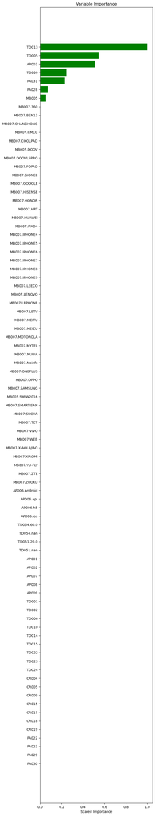

```python
def VarImp(model_name):

    import numpy as np
    from sklearn.metrics import roc_curve,auc
    from sklearn.metrics import average_precision_score
    from sklearn.metrics import precision_recall_curve
    import matplotlib.pyplot as plt

    # plot the variable importance
    plt.rcdefaults()
    variables = model_name._model_json['output']['variable_importances']['variable']
    y_pos = np.arange(len(variables))
    fig, ax = plt.subplots(figsize = (6,len(variables)/2))
    scaled_importance = model_name._model_json['output']['variable_importances']['scaled_importance']
    ax.barh(y_pos,scaled_importance,align='center',color='green')
    ax.set_yticks(y_pos)
    ax.set_yticklabels(variables)
    ax.invert_yaxis()
    ax.set_xlabel('Scaled Importance')
    ax.set_title('Variable Importance')
    plt.show()

VarImp(glm_v1)
```

```python
def createGains(model):
    import numpy as np
    predictions = model.predict(test_hex)['p1']
    test_scores = test_hex['loan_default'].cbind(predictions).as_data_frame()

    #sort on prediction (descending), add id, and decile for groups containing 1/10 of datapoints
    test_scores = test_scores.sort_values(by='p1',ascending=False)
    test_scores['row_id'] = range(0,0+len(test_scores))
    test_scores['decile'] = ( test_scores['row_id'] / (len(test_scores)/10) ).astype(int)
    #see count by decile
    test_scores.loc[test_scores['decile'] == 10]=9
    test_scores['decile'].value_counts()

    #create gains table
    gains = test_scores.groupby('decile')['loan_default'].agg(['count','sum'])
    gains.columns = ['count','actual']
    gains

    #add features to gains table
    gains['non_actual'] = gains['count'] - gains['actual']
    gains['cum_count'] = gains['count'].cumsum()
    gains['cum_actual'] = gains['actual'].cumsum()
    gains['cum_non_actual'] = gains['non_actual'].cumsum()
    gains['percent_cum_actual'] = (gains['cum_actual'] / np.max(gains['cum_actual'])).round(2)
    gains['percent_cum_non_actual'] = (gains['cum_non_actual'] / np.max(gains['cum_non_actual'])).round(2)
    gains['if_random'] = np.max(gains['cum_actual']) /10
    gains['if_random'] = gains['if_random'].cumsum()
    gains['lift'] = (gains['cum_actual'] / gains['if_random']).round(2)
    gains['K_S'] = np.abs( gains['percent_cum_actual'] -  gains['percent_cum_non_actual'] ) * 100
    gains['gain']=(gains['cum_actual']/gains['cum_count']*100).round(2)
    gains = pd.DataFrame(gains)
    return(gains)
```

```python
createGains(glm_v1)
```

```
glm prediction progress: |███████████████████████████████████████████████████████| (done) 100%
```

| decile | count | actual | non_actual | cum_count | cum_actual | cum_non_actual | percent_cum_actual | percent_cum_non_actual | if_random | lift | K_S | gain |
| --- | --- | --- | --- | --- | --- | --- | --- | --- | --- | --- | --- | --- |
| 0 | 240 | 82 | 158 | 240 | 82 | 158 | 0.17 | 0.08 | 49.0 | 1.67 | 9.0 | 34.17 |
| 1 | 240 | 62 | 178 | 480 | 144 | 336 | 0.29 | 0.18 | 98.0 | 1.47 | 11.0 | 30.00 |
| 2 | 240 | 60 | 180 | 720 | 204 | 516 | 0.42 | 0.27 | 147.0 | 1.39 | 15.0 | 28.33 |
| 3 | 240 | 62 | 178 | 960 | 266 | 694 | 0.54 | 0.36 | 196.0 | 1.36 | 18.0 | 27.71 |
| 4 | 240 | 49 | 191 | 1200 | 315 | 885 | 0.64 | 0.46 | 245.0 | 1.29 | 18.0 | 26.25 |
| 5 | 240 | 32 | 208 | 1440 | 347 | 1093 | 0.71 | 0.57 | 294.0 | 1.18 | 14.0 | 24.10 |
| 6 | 240 | 50 | 190 | 1680 | 397 | 1283 | 0.81 | 0.67 | 343.0 | 1.16 | 14.0 | 23.63 |
| 7 | 240 | 41 | 199 | 1920 | 438 | 1482 | 0.89 | 0.78 | 392.0 | 1.12 | 11.0 | 22.81 |
| 8 | 240 | 28 | 212 | 2160 | 466 | 1694 | 0.95 | 0.89 | 441.0 | 1.06 | 6.0 | 21.57 |
| 9 | 240 | 24 | 216 | 2400 | 490 | 1910 | 1.00 | 1.00 | 490.0 | 1.00 | 0.0 | 20.42 |

```python
def ROC_AUC(my_result,df,target):
    from sklearn.metrics import roc_curve,auc
    from sklearn.metrics import average_precision_score
    from sklearn.metrics import precision_recall_curve
    import matplotlib.pyplot as plt

    # ROC
    y_actual = df[target].as_data_frame()
    y_pred = my_result.predict(df)['p1'].as_data_frame()
    fpr = list()
    tpr = list()
    roc_auc = list()
    fpr,tpr,_ = roc_curve(y_actual,y_pred)
    roc_auc = auc(fpr,tpr)

    # Precision-Recall
    average_precision = average_precision_score(y_actual,y_pred)

    print('')
    print('   * ROC curve: The ROC curve plots the true positive rate vs. the false rositive sate')
    print('')
    print('	  * The area under the curve (AUC): A value between 0.5 (random) and 1.0 (perfect), measuring the prediction accuracy')
    print('')
    print('   * Recall (R) = The number of true positives / (the number of true positives + the number of false negatives)')
    print('')

    # plotting
    plt.figure(figsize=(10,4))

    # ROC
    plt.subplot(1,2,1)
    plt.plot(fpr,tpr,color='darkorange',lw=2,label='ROC curve (aare=%0.2f)' % roc_auc)
    plt.plot([0,1],[0,1],color='navy',lw=3,linestyle='--')
    plt.xlim([0.0,1.0])
    plt.ylim([0.0,1.05])
    plt.xlabel('False Positive Rate')
    plt.ylabel('True Positive Rate')
    plt.title('Receiver operating characteristic: AUC={0:0.4f}'.format(roc_auc))
    plt.legend(loc='lower right')

    # Precision-Recall
    plt.subplot(1,2,2)
    precision,recall,_ = precision_recall_curve(y_actual,y_pred)
    plt.step(recall,precision,color='b',alpha=0.2,where='post')
    plt.fill_between(recall,precision,step='post',alpha=0.2,color='b')
    plt.xlabel('Recall')
    plt.ylabel('Precision')
    plt.ylim([0.0,1.05])
    plt.xlim([0.0,1.0])
    plt.title('Precision-Recall curve: PR={0:0.4f}'.format(average_precision))
    plt.show()
```

```
glm prediction progress: |███████████████████████████████████████████████████████| (done) 100%

   * ROC curve: The ROC curve plots the true positive rate vs. the false rositive sate

	  * The area under the curve (AUC): A value between 0.5 (random) and 1.0 (perfect), measuring the prediction accuracy

   * Recall (R) = The number of true positives / (the number of true positives + the number of false negatives)
```

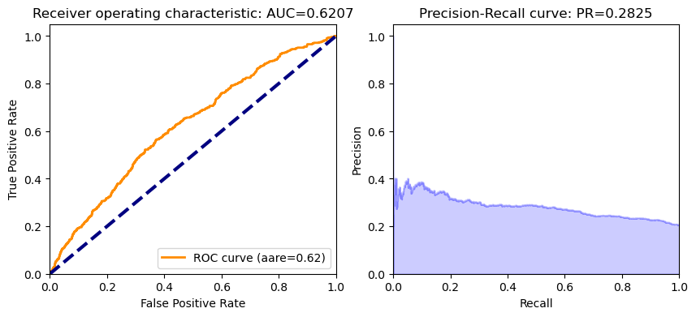

```python
ROC_AUC(glm_v1,test_hex,'loan_default')
```

Conclusion:

- This is the first attempt of modeling with training sample using default parameters
- The model's ROC curve has AUC score of 0.62.

The next step is to grid search for optimal hyperparameters

- use grid search to find alpha
- use lambda search to efficiently and automatically search for the optimal value of the lambda parameter

```python
from h2o.grid.grid_search import H2OGridSearch
hyper_params = {'alpha': [0, .25, .5, .75, .1]}
grid = H2OGridSearch(model = H2OGeneralizedLinearEstimator(family = 'binomial', lambda_search = True),
                     hyper_params = hyper_params,
                     search_criteria = {'strategy': "Cartesian"})
grid.train(predictors, target, training_frame = train_hex)
```

```
glm Grid Build progress: |███████████████████████████████████████████████████████| (done) 100%
```

```
     alpha  \
0     0.00
1     0.75
2     0.50
3     0.25
4     0.10

                                                               model_ids  \
0  Grid_GLM_Key_Frame__upload_a5d183edf4a222e13564678541ba4ac1.hex_mo...
1  Grid_GLM_Key_Frame__upload_a5d183edf4a222e13564678541ba4ac1.hex_mo...
2  Grid_GLM_Key_Frame__upload_a5d183edf4a222e13564678541ba4ac1.hex_mo...
3  Grid_GLM_Key_Frame__upload_a5d183edf4a222e13564678541ba4ac1.hex_mo...
4  Grid_GLM_Key_Frame__upload_a5d183edf4a222e13564678541ba4ac1.hex_mo...

    logloss
0  0.448895
1  0.449068
2  0.449129
3  0.449226
4  0.449662
```

```python
from h2o.estimators.glm import H2OGeneralizedLinearEstimator
glm_v2 = H2OGeneralizedLinearEstimator(family= "binomial",
                                        lambda_search = True,
                                      alpha = 0)
glm_v2.train(predictors, target, training_frame= train_hex)
```

```
glm Model Build progress: |
```

```
██████████████████████████████████████████████████████| (done) 100%
Model Details
=============
H2OGeneralizedLinearEstimator :  Generalized Linear Modeling
Model Key:  GLM_model_python_1659626312500_9


GLM Model: summary
```

|  |  | family | link | regularization | lambda_search | number_of_predictors_total | number_of_active_predictors | number_of_iterations | training_frame |
| --- | --- | --- | --- | --- | --- | --- | --- | --- | --- |
| 0 |  | binomial | logit | Ridge ( lambda = 5.529E-6 ) | nlambda = 30, lambda.max = 5.5287, lambda.min = 5.529E-6, lambda.1... | 85 | 85 | 56 | Key_Frame__upload_a5d183edf4a222e13564678541ba4ac1.hex |

```
ModelMetricsBinomialGLM: glm
** Reported on train data. **

MSE: 0.14184328768809004
RMSE: 0.37662088057898496
LogLoss: 0.4488952386751728
Null degrees of freedom: 5599
Residual degrees of freedom: 5514
Null deviance: 5404.868729982245
Residual deviance: 5027.6266731619335
AIC: 5199.6266731619335
AUC: 0.6850049188906332
AUCPR: 0.3328161166305902
Gini: 0.3700098377812664

Confusion Matrix (Act/Pred) for max f1 @ threshold = 0.22420872444123013:
```

|  |  | 0 | 1 | Error | Rate |
| --- | --- | --- | --- | --- | --- |
| 0 | 0 | 3465.0 | 1085.0 | 0.2385 | (1085.0/4550.0) |
| 1 | 1 | 520.0 | 530.0 | 0.4952 | (520.0/1050.0) |
| 2 | Total | 3985.0 | 1615.0 | 0.2866 | (1605.0/5600.0) |

```
Maximum Metrics: Maximum metrics at their respective thresholds
```

|  | metric | threshold | value | idx |
| --- | --- | --- | --- | --- |
| 0 | max f1 | 0.224209 | 0.397749 | 188.0 |
| 1 | max f2 | 0.123280 | 0.566211 | 300.0 |
| 2 | max f0point5 | 0.275313 | 0.367555 | 144.0 |
| 3 | max accuracy | 0.869398 | 0.813036 | 2.0 |
| 4 | max precision | 0.904388 | 1.000000 | 0.0 |
| 5 | max recall | 0.036690 | 1.000000 | 385.0 |
| 6 | max specificity | 0.904388 | 1.000000 | 0.0 |
| 7 | max absolute_mcc | 0.224209 | 0.229441 | 188.0 |
| 8 | max min_per_class_accuracy | 0.187359 | 0.628132 | 227.0 |
| 9 | max mean_per_class_accuracy | 0.200416 | 0.634799 | 213.0 |
| 10 | max tns | 0.904388 | 4550.000000 | 0.0 |
| 11 | max fns | 0.904388 | 1049.000000 | 0.0 |
| 12 | max fps | 0.002442 | 4550.000000 | 399.0 |
| 13 | max tps | 0.036690 | 1050.000000 | 385.0 |
| 14 | max tnr | 0.904388 | 1.000000 | 0.0 |
| 15 | max fnr | 0.904388 | 0.999048 | 0.0 |
| 16 | max fpr | 0.002442 | 1.000000 | 399.0 |
| 17 | max tpr | 0.036690 | 1.000000 | 385.0 |

```
Gains/Lift Table: Avg response rate: 18.75 %, avg score: 18.75 %
```

|  | group | cumulative_data_fraction | lower_threshold | lift | cumulative_lift | response_rate | score | cumulative_response_rate | cumulative_score | capture_rate | cumulative_capture_rate | gain | cumulative_gain | kolmogorov_smirnov |
| --- | --- | --- | --- | --- | --- | --- | --- | --- | --- | --- | --- | --- | --- | --- |
| 0 | 1 | 0.01 | 0.524196 | 2.476190 | 2.476190 | 0.464286 | 0.608713 | 0.464286 | 0.608713 | 0.024762 | 0.024762 | 147.619048 | 147.619048 | 0.018168 |
| 1 | 2 | 0.02 | 0.469248 | 2.380952 | 2.428571 | 0.446429 | 0.495493 | 0.455357 | 0.552103 | 0.023810 | 0.048571 | 138.095238 | 142.857143 | 0.035165 |
| 2 | 3 | 0.03 | 0.429487 | 2.761905 | 2.539683 | 0.517857 | 0.449289 | 0.476190 | 0.517831 | 0.027619 | 0.076190 | 176.190476 | 153.968254 | 0.056850 |
| 3 | 4 | 0.04 | 0.402706 | 2.380952 | 2.500000 | 0.446429 | 0.414740 | 0.468750 | 0.492058 | 0.023810 | 0.100000 | 138.095238 | 150.000000 | 0.073846 |
| 4 | 5 | 0.05 | 0.383101 | 2.285714 | 2.457143 | 0.428571 | 0.391044 | 0.460714 | 0.471856 | 0.022857 | 0.122857 | 128.571429 | 145.714286 | 0.089670 |
| 5 | 6 | 0.10 | 0.320583 | 1.961905 | 2.209524 | 0.367857 | 0.346142 | 0.414286 | 0.408999 | 0.098095 | 0.220952 | 96.190476 | 120.952381 | 0.148864 |
| 6 | 7 | 0.15 | 0.284879 | 1.695238 | 2.038095 | 0.317857 | 0.301051 | 0.382143 | 0.373016 | 0.084762 | 0.305714 | 69.523810 | 103.809524 | 0.191648 |
| 7 | 8 | 0.20 | 0.258541 | 1.466667 | 1.895238 | 0.275000 | 0.271018 | 0.355357 | 0.347517 | 0.073333 | 0.379048 | 46.666667 | 89.523810 | 0.220366 |
| 8 | 9 | 0.30 | 0.220324 | 1.342857 | 1.711111 | 0.251786 | 0.237882 | 0.320833 | 0.310972 | 0.134286 | 0.513333 | 34.285714 | 71.111111 | 0.262564 |
| 9 | 10 | 0.40 | 0.191886 | 1.009524 | 1.535714 | 0.189286 | 0.205673 | 0.287946 | 0.284647 | 0.100952 | 0.614286 | 0.952381 | 53.571429 | 0.263736 |
| 10 | 11 | 0.50 | 0.168804 | 0.895238 | 1.407619 | 0.167857 | 0.179911 | 0.263929 | 0.263700 | 0.089524 | 0.703810 | -10.476190 | 40.761905 | 0.250842 |
| 11 | 12 | 0.60 | 0.146859 | 0.866667 | 1.317460 | 0.162500 | 0.157392 | 0.247024 | 0.245982 | 0.086667 | 0.790476 | -13.333333 | 31.746032 | 0.234432 |
| 12 | 13 | 0.70 | 0.125142 | 0.809524 | 1.244898 | 0.151786 | 0.135993 | 0.233418 | 0.230269 | 0.080952 | 0.871429 | -19.047619 | 24.489796 | 0.210989 |
| 13 | 14 | 0.80 | 0.103914 | 0.571429 | 1.160714 | 0.107143 | 0.114590 | 0.217634 | 0.215809 | 0.057143 | 0.928571 | -42.857143 | 16.071429 | 0.158242 |
| 14 | 15 | 0.90 | 0.078653 | 0.409524 | 1.077249 | 0.076786 | 0.091470 | 0.201984 | 0.201994 | 0.040952 | 0.969524 | -59.047619 | 7.724868 | 0.085568 |
| 15 | 16 | 1.00 | 0.002442 | 0.304762 | 1.000000 | 0.057143 | 0.057109 | 0.187500 | 0.187505 | 0.030476 | 1.000000 | -69.523810 | 0.000000 | 0.000000 |

```
Scoring History:
```

|  |  | timestamp | duration | iteration | lambda | predictors | deviance_train | alpha | iterations | training_rmse | training_logloss | training_r2 | training_auc | training_pr_auc | training_lift | training_classification_error |
| --- | --- | --- | --- | --- | --- | --- | --- | --- | --- | --- | --- | --- | --- | --- | --- | --- |
| 0 |  | 2022-08-04 11:23:21 | 0.000 sec | 2 | .55E1 | 86 | 0.957477 | 0.0 | NaN |  |  |  |  |  |  |  |
| 1 |  | 2022-08-04 11:23:21 | 0.005 sec | 4 | .34E1 | 86 | 0.954048 | 0.0 | NaN |  |  |  |  |  |  |  |
| 2 |  | 2022-08-04 11:23:21 | 0.011 sec | 6 | .21E1 | 86 | 0.949754 | 0.0 | NaN |  |  |  |  |  |  |  |
| 3 |  | 2022-08-04 11:23:21 | 0.020 sec | 8 | .13E1 | 86 | 0.944812 | 0.0 | NaN |  |  |  |  |  |  |  |
| 4 |  | 2022-08-04 11:23:21 | 0.027 sec | 10 | .82E0 | 86 | 0.939518 | 0.0 | NaN |  |  |  |  |  |  |  |
| 5 |  | 2022-08-04 11:23:21 | 0.033 sec | 12 | .51E0 | 86 | 0.934101 | 0.0 | NaN |  |  |  |  |  |  |  |
| 6 |  | 2022-08-04 11:23:21 | 0.041 sec | 14 | .32E0 | 86 | 0.928731 | 0.0 | NaN |  |  |  |  |  |  |  |
| 7 |  | 2022-08-04 11:23:22 | 0.046 sec | 16 | .2E0 | 86 | 0.923584 | 0.0 | NaN |  |  |  |  |  |  |  |
| 8 |  | 2022-08-04 11:23:22 | 0.053 sec | 18 | .12E0 | 86 | 0.918906 | 0.0 | NaN |  |  |  |  |  |  |  |
| 9 |  | 2022-08-04 11:23:22 | 0.061 sec | 20 | .76E-1 | 86 | 0.914943 | 0.0 | NaN |  |  |  |  |  |  |  |
| 10 |  | 2022-08-04 11:23:22 | 0.066 sec | 22 | .47E-1 | 86 | 0.911818 | 0.0 | NaN |  |  |  |  |  |  |  |
| 11 |  | 2022-08-04 11:23:22 | 0.072 sec | 24 | .29E-1 | 86 | 0.909482 | 0.0 | NaN |  |  |  |  |  |  |  |
| 12 |  | 2022-08-04 11:23:22 | 0.078 sec | 26 | .18E-1 | 86 | 0.907769 | 0.0 | NaN |  |  |  |  |  |  |  |
| 13 |  | 2022-08-04 11:23:22 | 0.084 sec | 28 | .11E-1 | 86 | 0.906485 | 0.0 | NaN |  |  |  |  |  |  |  |
| 14 |  | 2022-08-04 11:23:22 | 0.089 sec | 30 | .7E-2 | 86 | 0.905481 | 0.0 | NaN |  |  |  |  |  |  |  |
| 15 |  | 2022-08-04 11:23:22 | 0.094 sec | 32 | .44E-2 | 86 | 0.904652 | 0.0 | NaN |  |  |  |  |  |  |  |
| 16 |  | 2022-08-04 11:23:22 | 0.100 sec | 34 | .27E-2 | 86 | 0.903932 | 0.0 | NaN |  |  |  |  |  |  |  |
| 17 |  | 2022-08-04 11:23:22 | 0.105 sec | 36 | .17E-2 | 86 | 0.903278 | 0.0 | NaN |  |  |  |  |  |  |  |
| 18 |  | 2022-08-04 11:23:22 | 0.111 sec | 38 | .1E-2 | 86 | 0.902674 | 0.0 | NaN |  |  |  |  |  |  |  |
| 19 |  | 2022-08-04 11:23:22 | 0.117 sec | 40 | .65E-3 | 86 | 0.902107 | 0.0 | NaN |  |  |  |  |  |  |  |

```
See the whole table with table.as_data_frame()

Variable Importances:
```

|  | variable | relative_importance | scaled_importance | percentage |
| --- | --- | --- | --- | --- |
| 0 | MB007.SM-W2016 | 3.977644 | 1.000000 | 0.065157 |
| 1 | MB007.ZUOKU | 3.594096 | 0.903574 | 0.058874 |
| 2 | MB007.TCT | 2.927749 | 0.736051 | 0.047959 |
| 3 | MB007.LETV | 2.642440 | 0.664323 | 0.043285 |
| 4 | MB007.HISENSE | 2.282578 | 0.573852 | 0.037391 |
| 5 | MB007.CHANGHONG | 2.261636 | 0.568587 | 0.037047 |
| 6 | MB007.COOLPAD | 2.100676 | 0.528121 | 0.034411 |
| 7 | MB007.LENOVO | 2.083150 | 0.523715 | 0.034124 |
| 8 | MB007.SMARTISAN | 2.027191 | 0.509646 | 0.033207 |
| 9 | MB007.ONEPLUS | 1.591522 | 0.400117 | 0.026070 |
| 10 | MB007.GIONEE | 1.568955 | 0.394443 | 0.025701 |
| 11 | MB007.MOTOROLA | 1.427278 | 0.358825 | 0.023380 |
| 12 | MB007.DOOV | 1.420829 | 0.357204 | 0.023274 |
| 13 | MB007.MYTEL | 1.332328 | 0.334954 | 0.021825 |
| 14 | MB007.IPAD4 | 1.269627 | 0.319191 | 0.020798 |
| 15 | MB007.BEN13 | 1.266610 | 0.318432 | 0.020748 |
| 16 | MB007.SUGAR | 1.259953 | 0.316759 | 0.020639 |
| 17 | MB007.CMCC | 1.240999 | 0.311994 | 0.020329 |
| 18 | MB007.ZTE | 1.199734 | 0.301619 | 0.019653 |
| 19 | MB007.GOOGLE | 1.189818 | 0.299126 | 0.019490 |

```
See the whole table with table.as_data_frame()
```

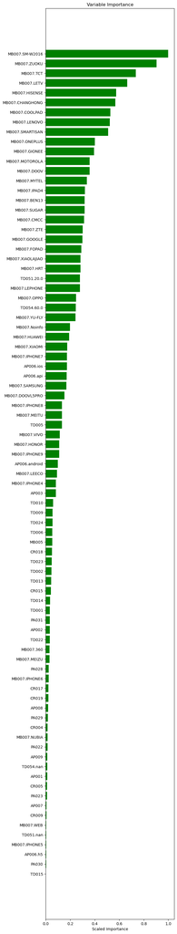

```python
VarImp(glm_v2)
```

```python
createGains(glm_v2)
```

```
glm prediction progress: |███████████████████████████████████████████████████████| (done) 100%
```

| decile | count | actual | non_actual | cum_count | cum_actual | cum_non_actual | percent_cum_actual | percent_cum_non_actual | if_random | lift | K_S | gain |
| --- | --- | --- | --- | --- | --- | --- | --- | --- | --- | --- | --- | --- |
| 0 | 240 | 82 | 158 | 240 | 82 | 158 | 0.17 | 0.08 | 49.0 | 1.67 | 9.0 | 34.17 |
| 1 | 240 | 77 | 163 | 480 | 159 | 321 | 0.32 | 0.17 | 98.0 | 1.62 | 15.0 | 33.12 |
| 2 | 240 | 55 | 185 | 720 | 214 | 506 | 0.44 | 0.26 | 147.0 | 1.46 | 18.0 | 29.72 |
| 3 | 240 | 64 | 176 | 960 | 278 | 682 | 0.57 | 0.36 | 196.0 | 1.42 | 21.0 | 28.96 |
| 4 | 240 | 53 | 187 | 1200 | 331 | 869 | 0.68 | 0.45 | 245.0 | 1.35 | 23.0 | 27.58 |
| 5 | 240 | 43 | 197 | 1440 | 374 | 1066 | 0.76 | 0.56 | 294.0 | 1.27 | 20.0 | 25.97 |
| 6 | 240 | 41 | 199 | 1680 | 415 | 1265 | 0.85 | 0.66 | 343.0 | 1.21 | 19.0 | 24.70 |
| 7 | 240 | 35 | 205 | 1920 | 450 | 1470 | 0.92 | 0.77 | 392.0 | 1.15 | 15.0 | 23.44 |
| 8 | 240 | 26 | 214 | 2160 | 476 | 1684 | 0.97 | 0.88 | 441.0 | 1.08 | 9.0 | 22.04 |
| 9 | 240 | 14 | 226 | 2400 | 490 | 1910 | 1.00 | 1.00 | 490.0 | 1.00 | 0.0 | 20.42 |

```
glm prediction progress: |███████████████████████████████████████████████████████| (done) 100%

   * ROC curve: The ROC curve plots the true positive rate vs. the false rositive sate

	  * The area under the curve (AUC): A value between 0.5 (random) and 1.0 (perfect), measuring the prediction accuracy

   * Recall (R) = The number of true positives / (the number of true positives + the number of false negatives)
```

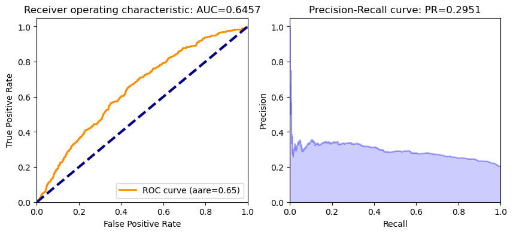

```python
ROC_AUC(glm_v2,test_hex,'loan_default')
```

Conclusion:

- The tuned model has improved performance
- The AUC score increased from 0.62 to 0.65.

#### model with entire dataset

- use the tuned hyperparameters

```python
# entire dataset
train_hex = h2o.H2OFrame(train)
test_hex = h2o.H2OFrame(test)
```

```
Parse progress: |████████████████████████████████████████████████████████████████| (done) 100%
Parse progress: |████████████████████████████████████████████████████████████████| (done) 100%
```

```python
from h2o.estimators.glm import H2OGeneralizedLinearEstimator
glm_v3 = H2OGeneralizedLinearEstimator(family= "binomial",
                                        lambda_search = True,
                                      alpha = 0)
glm_v3.train(predictors, target, training_frame= train_hex)
```

```
glm Model Build progress: |
```

```
██████████████████████████████████████████████████████| (done) 100%
Model Details
=============
H2OGeneralizedLinearEstimator :  Generalized Linear Modeling
Model Key:  GLM_model_python_1659626312500_11


GLM Model: summary
```

|  |  | family | link | regularization | lambda_search | number_of_predictors_total | number_of_active_predictors | number_of_iterations | training_frame |
| --- | --- | --- | --- | --- | --- | --- | --- | --- | --- |
| 0 |  | binomial | logit | Ridge ( lambda = 5.693E-4 ) | nlambda = 30, lambda.max = 5.6929, lambda.min = 5.693E-4, lambda.1... | 42845 | 42845 | 56 | Key_Frame__upload_bc820d95e0228657b604d4547a544011.hex |

```
ModelMetricsBinomialGLM: glm
** Reported on train data. **

MSE: 0.14761558375249803
RMSE: 0.38420773515443185
LogLoss: 0.46417325951706334
Null degrees of freedom: 55999
Residual degrees of freedom: 13154
Null deviance: 54975.232388000404
Residual deviance: 51987.405065911094
AIC: 137679.4050659111
AUC: 0.6659303431171596
AUCPR: 0.3114501677422611
Gini: 0.3318606862343192

Confusion Matrix (Act/Pred) for max f1 @ threshold = 0.17611568753609186:
```

|  |  | 0 | 1 | Error | Rate |
| --- | --- | --- | --- | --- | --- |
| 0 | 0 | 24314.0 | 20866.0 | 0.4618 | (20866.0/45180.0) |
| 1 | 1 | 3243.0 | 7577.0 | 0.2997 | (3243.0/10820.0) |
| 2 | Total | 27557.0 | 28443.0 | 0.4305 | (24109.0/56000.0) |

```
Maximum Metrics: Maximum metrics at their respective thresholds
```

|  | metric | threshold | value | idx |
| --- | --- | --- | --- | --- |
| 0 | max f1 | 0.176116 | 0.385961 | 256.0 |
| 1 | max f2 | 0.116908 | 0.564708 | 327.0 |
| 2 | max f0point5 | 0.258046 | 0.340185 | 170.0 |
| 3 | max accuracy | 0.627159 | 0.806929 | 15.0 |
| 4 | max precision | 0.691753 | 0.600000 | 8.0 |
| 5 | max recall | 0.033721 | 1.000000 | 396.0 |
| 6 | max specificity | 0.845050 | 0.999978 | 0.0 |
| 7 | max absolute_mcc | 0.201587 | 0.192529 | 227.0 |
| 8 | max min_per_class_accuracy | 0.192345 | 0.616467 | 238.0 |
| 9 | max mean_per_class_accuracy | 0.185521 | 0.619237 | 245.0 |
| 10 | max tns | 0.845050 | 45179.000000 | 0.0 |
| 11 | max fns | 0.845050 | 10819.000000 | 0.0 |
| 12 | max fps | 0.011668 | 45180.000000 | 399.0 |
| 13 | max tps | 0.033721 | 10820.000000 | 396.0 |
| 14 | max tnr | 0.845050 | 0.999978 | 0.0 |
| 15 | max fnr | 0.845050 | 0.999908 | 0.0 |
| 16 | max fpr | 0.011668 | 1.000000 | 399.0 |
| 17 | max tpr | 0.033721 | 1.000000 | 396.0 |

```
Gains/Lift Table: Avg response rate: 19.32 %, avg score: 19.25 %
```

|  | group | cumulative_data_fraction | lower_threshold | lift | cumulative_lift | response_rate | score | cumulative_response_rate | cumulative_score | capture_rate | cumulative_capture_rate | gain | cumulative_gain | kolmogorov_smirnov |
| --- | --- | --- | --- | --- | --- | --- | --- | --- | --- | --- | --- | --- | --- | --- |
| 0 | 1 | 0.01 | 0.478072 | 2.310536 | 2.310536 | 0.446429 | 0.542551 | 0.446429 | 0.542551 | 0.023105 | 0.023105 | 131.053604 | 131.053604 | 0.016244 |
| 1 | 2 | 0.02 | 0.428136 | 2.356747 | 2.333641 | 0.455357 | 0.451494 | 0.450893 | 0.497022 | 0.023567 | 0.046673 | 135.674677 | 133.364140 | 0.033061 |
| 2 | 3 | 0.03 | 0.399986 | 1.996303 | 2.221195 | 0.385714 | 0.413444 | 0.429167 | 0.469163 | 0.019963 | 0.066636 | 99.630314 | 122.119532 | 0.045410 |
| 3 | 4 | 0.04 | 0.378541 | 1.987061 | 2.162662 | 0.383929 | 0.388834 | 0.417857 | 0.449081 | 0.019871 | 0.086506 | 98.706100 | 116.266174 | 0.057644 |
| 4 | 5 | 0.05 | 0.361035 | 1.876155 | 2.105360 | 0.362500 | 0.369184 | 0.406786 | 0.433101 | 0.018762 | 0.105268 | 87.615527 | 110.536044 | 0.068504 |
| 5 | 6 | 0.10 | 0.310274 | 1.804067 | 1.954713 | 0.348571 | 0.332675 | 0.377679 | 0.382888 | 0.090203 | 0.195471 | 80.406654 | 95.471349 | 0.118335 |
| 6 | 7 | 0.15 | 0.279256 | 1.571165 | 1.826864 | 0.303571 | 0.293572 | 0.352976 | 0.353116 | 0.078558 | 0.274030 | 57.116451 | 82.686383 | 0.153733 |
| 7 | 8 | 0.20 | 0.256677 | 1.521257 | 1.750462 | 0.293929 | 0.267420 | 0.338214 | 0.331692 | 0.076063 | 0.350092 | 52.125693 | 75.046211 | 0.186038 |
| 8 | 9 | 0.30 | 0.223471 | 1.258780 | 1.586568 | 0.243214 | 0.238948 | 0.306548 | 0.300777 | 0.125878 | 0.475970 | 25.878004 | 58.656808 | 0.218113 |
| 9 | 10 | 0.40 | 0.198303 | 1.158041 | 1.479436 | 0.223750 | 0.210525 | 0.285848 | 0.278214 | 0.115804 | 0.591774 | 15.804067 | 47.943623 | 0.237702 |
| 10 | 11 | 0.50 | 0.177394 | 0.998152 | 1.383179 | 0.192857 | 0.187470 | 0.267250 | 0.260065 | 0.099815 | 0.691590 | -0.184843 | 38.317930 | 0.237473 |
| 11 | 12 | 0.60 | 0.157565 | 0.894640 | 1.301756 | 0.172857 | 0.167283 | 0.251518 | 0.244602 | 0.089464 | 0.781054 | -10.536044 | 30.175601 | 0.224413 |
| 12 | 13 | 0.70 | 0.138288 | 0.718115 | 1.218379 | 0.138750 | 0.147940 | 0.235408 | 0.230793 | 0.071811 | 0.852865 | -28.188540 | 21.837866 | 0.189474 |
| 13 | 14 | 0.80 | 0.118182 | 0.657116 | 1.148221 | 0.126964 | 0.128560 | 0.221853 | 0.218014 | 0.065712 | 0.918577 | -34.288355 | 14.822089 | 0.146974 |
| 14 | 15 | 0.90 | 0.093671 | 0.483364 | 1.074348 | 0.093393 | 0.106793 | 0.207579 | 0.205656 | 0.048336 | 0.966913 | -51.663586 | 7.434792 | 0.082938 |
| 15 | 16 | 1.00 | 0.011668 | 0.330869 | 1.000000 | 0.063929 | 0.074489 | 0.193214 | 0.192539 | 0.033087 | 1.000000 | -66.913124 | 0.000000 | 0.000000 |

```
Scoring History:
```

|  |  | timestamp | duration | iteration | lambda | predictors | deviance_train | alpha | iterations | training_rmse | training_logloss | training_r2 | training_auc | training_pr_auc | training_lift | training_classification_error |
| --- | --- | --- | --- | --- | --- | --- | --- | --- | --- | --- | --- | --- | --- | --- | --- | --- |
| 0 |  | 2022-08-04 11:24:30 | 0.000 sec | 2 | .57E1 | 42846 | 0.973697 | 0.0 | NaN |  |  |  |  |  |  |  |
| 1 |  | 2022-08-04 11:24:30 | 0.046 sec | 4 | .41E1 | 42846 | 0.971444 | 0.0 | NaN |  |  |  |  |  |  |  |
| 2 |  | 2022-08-04 11:24:30 | 0.080 sec | 6 | .3E1 | 42846 | 0.968812 | 0.0 | NaN |  |  |  |  |  |  |  |
| 3 |  | 2022-08-04 11:24:30 | 0.115 sec | 8 | .22E1 | 42846 | 0.965849 | 0.0 | NaN |  |  |  |  |  |  |  |
| 4 |  | 2022-08-04 11:24:30 | 0.151 sec | 10 | .16E1 | 42846 | 0.962645 | 0.0 | NaN |  |  |  |  |  |  |  |
| 5 |  | 2022-08-04 11:24:30 | 0.184 sec | 12 | .12E1 | 42846 | 0.959305 | 0.0 | NaN |  |  |  |  |  |  |  |
| 6 |  | 2022-08-04 11:24:30 | 0.214 sec | 14 | .85E0 | 42846 | 0.955922 | 0.0 | NaN |  |  |  |  |  |  |  |
| 7 |  | 2022-08-04 11:24:30 | 0.248 sec | 16 | .62E0 | 42846 | 0.952563 | 0.0 | NaN |  |  |  |  |  |  |  |
| 8 |  | 2022-08-04 11:24:31 | 0.292 sec | 19 | .45E0 | 42846 | 0.949225 | 0.0 | NaN |  |  |  |  |  |  |  |
| 9 |  | 2022-08-04 11:24:31 | 0.331 sec | 22 | .33E0 | 42846 | 0.945983 | 0.0 | NaN |  |  |  |  |  |  |  |
| 10 |  | 2022-08-04 11:24:31 | 0.365 sec | 25 | .24E0 | 42846 | 0.942885 | 0.0 | NaN |  |  |  |  |  |  |  |
| 11 |  | 2022-08-04 11:24:31 | 0.400 sec | 28 | .17E0 | 42846 | 0.939965 | 0.0 | NaN |  |  |  |  |  |  |  |
| 12 |  | 2022-08-04 11:24:31 | 0.431 sec | 31 | .13E0 | 42846 | 0.937314 | 0.0 | NaN |  |  |  |  |  |  |  |
| 13 |  | 2022-08-04 11:24:31 | 0.461 sec | 34 | .92E-1 | 42846 | 0.935009 | 0.0 | NaN |  |  |  |  |  |  |  |
| 14 |  | 2022-08-04 11:24:31 | 0.495 sec | 37 | .67E-1 | 42846 | 0.933097 | 0.0 | NaN |  |  |  |  |  |  |  |
| 15 |  | 2022-08-04 11:24:31 | 0.527 sec | 40 | .49E-1 | 42846 | 0.931584 | 0.0 | NaN |  |  |  |  |  |  |  |
| 16 |  | 2022-08-04 11:24:31 | 0.537 sec | 41 | .35E-1 | 42846 | 0.930998 | 0.0 | NaN |  |  |  |  |  |  |  |
| 17 |  | 2022-08-04 11:24:31 | 0.562 sec | 44 | .26E-1 | 42846 | 0.929664 | 0.0 | NaN |  |  |  |  |  |  |  |
| 18 |  | 2022-08-04 11:24:31 | 0.573 sec | 45 | .19E-1 | 42846 | 0.929443 | 0.0 | NaN |  |  |  |  |  |  |  |
| 19 |  | 2022-08-04 11:24:31 | 0.580 sec | 46 | .14E-1 | 42846 | 0.929367 | 0.0 | NaN |  |  |  |  |  |  |  |

```
See the whole table with table.as_data_frame()

Variable Importances:
```

|  | variable | relative_importance | scaled_importance | percentage |
| --- | --- | --- | --- | --- |
| 0 | AP003 | 0.344912 | 1.000000 | 0.026554 |
| 1 | MB005 | 0.191354 | 0.554790 | 0.014732 |
| 2 | TD013 | 0.135662 | 0.393324 | 0.010444 |
| 3 | CR015 | 0.127530 | 0.369746 | 0.009818 |
| 4 | AP006.android | 0.117988 | 0.342082 | 0.009084 |
| 5 | AP002 | 0.107838 | 0.312653 | 0.008302 |
| 6 | TD001 | 0.081897 | 0.237442 | 0.006305 |
| 7 | TD009 | 0.077397 | 0.224396 | 0.005959 |
| 8 | TD005 | 0.070745 | 0.205111 | 0.005447 |
| 9 | AP008 | 0.056470 | 0.163722 | 0.004347 |
| 10 | CR018 | 0.056265 | 0.163130 | 0.004332 |
| 11 | AP006.ios | 0.053577 | 0.155336 | 0.004125 |
| 12 | CR004 | 0.053237 | 0.154350 | 0.004099 |
| 13 | AP006.h5 | 0.049053 | 0.142218 | 0.003776 |
| 14 | MB007.VIVO | 0.047189 | 0.136815 | 0.003633 |
| 15 | AP009 | 0.047117 | 0.136606 | 0.003627 |
| 16 | AP007 | 0.046997 | 0.136257 | 0.003618 |
| 17 | MB007.WEB | 0.046197 | 0.133938 | 0.003557 |
| 18 | MB007.OPPO | 0.045064 | 0.130655 | 0.003469 |
| 19 | PA029 | 0.044210 | 0.128178 | 0.003404 |

```
See the whole table with table.as_data_frame()
```

```python
def VarImp_top(model_name):

    import numpy as np
    from sklearn.metrics import roc_curve,auc
    from sklearn.metrics import average_precision_score
    from sklearn.metrics import precision_recall_curve
    import matplotlib.pyplot as plt

    # plot the variable importance
    plt.rcdefaults()
    variables = model_name._model_json['output']['variable_importances']['variable'][:10]
    y_pos = np.arange(len(variables))
    fig, ax = plt.subplots(figsize = (6,len(variables)/2))
    scaled_importance = model_name._model_json['output']['variable_importances']['scaled_importance'][:10]
    ax.barh(y_pos,scaled_importance,align='center',color='green')
    ax.set_yticks(y_pos)
    ax.set_yticklabels(variables)
    ax.invert_yaxis()
    ax.set_xlabel('Scaled Importance')
    ax.set_title('Variable Importance')
    plt.show()
```

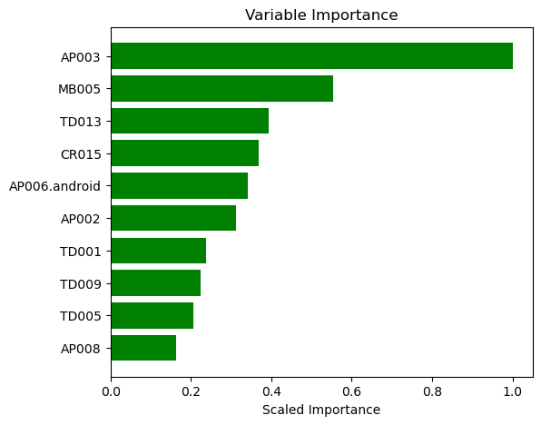

```python
VarImp_top(glm_v3)
```

```python
createGains(glm_v3)
```

```
glm prediction progress: |███████████████████████████████████████████████████████| (done) 100%
```

| decile | count | actual | non_actual | cum_count | cum_actual | cum_non_actual | percent_cum_actual | percent_cum_non_actual | if_random | lift | K_S | gain |
| --- | --- | --- | --- | --- | --- | --- | --- | --- | --- | --- | --- | --- |
| 0 | 2400 | 889 | 1511 | 2400 | 889 | 1511 | 0.19 | 0.08 | 466.8 | 1.90 | 11.0 | 37.04 |
| 1 | 2400 | 713 | 1687 | 4800 | 1602 | 3198 | 0.34 | 0.17 | 933.6 | 1.72 | 17.0 | 33.38 |
| 2 | 2400 | 584 | 1816 | 7200 | 2186 | 5014 | 0.47 | 0.26 | 1400.4 | 1.56 | 21.0 | 30.36 |
| 3 | 2400 | 535 | 1865 | 9600 | 2721 | 6879 | 0.58 | 0.36 | 1867.2 | 1.46 | 22.0 | 28.34 |
| 4 | 2400 | 479 | 1921 | 12000 | 3200 | 8800 | 0.69 | 0.46 | 2334.0 | 1.37 | 23.0 | 26.67 |
| 5 | 2400 | 410 | 1990 | 14400 | 3610 | 10790 | 0.77 | 0.56 | 2800.8 | 1.29 | 21.0 | 25.07 |
| 6 | 2400 | 319 | 2081 | 16800 | 3929 | 12871 | 0.84 | 0.67 | 3267.6 | 1.20 | 17.0 | 23.39 |
| 7 | 2400 | 303 | 2097 | 19200 | 4232 | 14968 | 0.91 | 0.77 | 3734.4 | 1.13 | 14.0 | 22.04 |
| 8 | 2400 | 253 | 2147 | 21600 | 4485 | 17115 | 0.96 | 0.89 | 4201.2 | 1.07 | 7.0 | 20.76 |
| 9 | 2400 | 183 | 2217 | 24000 | 4668 | 19332 | 1.00 | 1.00 | 4668.0 | 1.00 | 0.0 | 19.45 |

The bank can choose to underwrite Segment 7 to 9 and avoid Segment 0 to 3.

```
glm prediction progress: |███████████████████████████████████████████████████████| (done) 100%

   * ROC curve: The ROC curve plots the true positive rate vs. the false rositive sate

	  * The area under the curve (AUC): A value between 0.5 (random) and 1.0 (perfect), measuring the prediction accuracy

   * Recall (R) = The number of true positives / (the number of true positives + the number of false negatives)
```

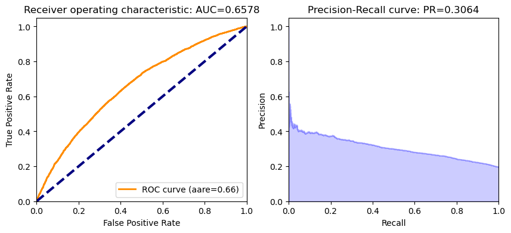

```python
ROC_AUC(glm_v3,test_hex,'loan_default')
```

#### Conclusion:

- Train the model using entire training dataset, use all features and tuned hyperparameters (with regularization)
- The top three important features are AP003, MB005, TD013.
- The maximum lift is 1.90 and ROC curve has AUC score of 0.66.